# Thresh-task macBP gamma & odor-condition spectrograms

Zelano Lab — threshTask analysis

2026-07-01

## 1. Methods

**Data.** Thresh-task intracranial/scalp recordings, preprocessed to 500 Hz (high-pass 0.03 Hz, low-pass ~Nyquist, notch 60/120/180 Hz). Analysis channels are the bipolar macro pairs `macBP1..5` (count varies; sessions without any `macBP` are excluded). Sessions are grouped as **DupiS1 / DupiS2 / DupiS3** (Dupi study, recording session 1/2/3) and **Control** (all non-Dupi thresh sessions).

**Design.** Each thresh session is 45 single-sniff trials. Every trial delivers one of three odorants — **air** (clean-air control), **low**, or **med** (two PEA concentrations) — and the participant makes one cued sniff per trial. The sniff onset (`finalOnset`, respiration-phase refined) is the response event; `TTL.start` (= sniff − 2 s @500 Hz) is the pre-sniff marker used as the baseline anchor.

**FOOOF (Task 1).** Per session, each `macBP` PSD (FieldTrip `ft_freqanalysis`, `mtmfft`, 2 s segments, 50% overlap, piped in via EEGLAB `eeglab2fieldtrip`) was parameterized with FOOOF over **2–58 Hz** with a **knee** aperiodic term (`cfg.output = fooof_aperiodic / fooof_peaks`; brainstorm `process_fooof`). The **gamma** band is 30–58 Hz. Before selecting `bestMac`, each channel’s **trial-rejection rate** is estimated (fraction of `TTL.start` epochs flagged noisy by the relative sharp-deflection rule, below); channels exceeding **30%** are excluded from bestMac consideration, preventing a high-noise channel whose broadband artifact mimics a gamma peak from being selected. Among the remaining (clean) channels: `bestMac` is the channel with the largest **periodic** gamma peak; if no clean channel has a fitted gamma peak we fall back to the largest **flattened** (PSD ÷ aperiodic) power; if all channels exceed 30% we select the least-noisy one (`selectionMethod = 'allNoisy_leastBad'`). The `selectionMethod` and per-channel `rejRate` columns record the outcome.

**Spectrograms (z-score method), split by odor condition.** For each session’s `bestMac`, per-trial time-frequency power was obtained from EEGLAB `newtimef` (Morlet, 100 log-spaced freqs 2–120 Hz; single-trial `alltfX` → |·|²), locked to the **sniff onset (finalOnset)**. Trials were split three ways by odor condition (`behDat.type` ∈ {air, low, med}), all finalOnset-locked. Power was normalized with a **bootstrap permutation z-score** (`myChanZscore`): per frequency, each condition’s finalOnset epochs are z-scored against **those same trials’ pre-`start` baseline** — the **−700…−200 ms** window relative to `TTL.start`, appended per-trial before z-scoring (exactly as cue z-scores finalOnset against its trialStart baseline). Because `start = sniff − 2 s`, this baseline sits ~2.2–2.7 s before the sniff, a clean pre-stimulus reference. All three condition maps use one identical baseline **definition**; they differ only in *which trials* feed them (~15 trials each, minus noise). Display window −1000…+3000 ms; the **mean respiration trace** (chosen `rsp` channel, flipped) is overlaid (black line, right axis). Group means (Task 4) average the per-subject z maps (and respiration) within each group × condition on one shared color scale.

*Noise rejection (relative sharp-deflection rule).* Sharp deflections are detected **relative to each channel’s own variability**, so a uniformly high-amplitude channel is not rejected merely for being high-amplitude. For the `bestMac` trace we compute the sliding 10 ms max-to-min range `d` and robust-z it over the **whole recording**: `zd = (d − median(d)) / (1.4826·MAD(d))` — how many robust-SDs a given 10 ms swing sits above that channel’s *typical* 10 ms swing. A 10 ms window is an **event** if `zd > K`, and a trial (`TTL.start`-locked epoch −1.75…+5.75 s) is flagged **noisy** if it contains any event. The threshold **K = 10** was calibrated once across the dataset (`thresh_calibrate_noise`) to drop >0 % and ≤20 % of trials; the same K applies to every session. Noisy trials are drawn in **red** on `singleTrialRawMac.png` and excluded from all spectrograms and from the gamma analysis.

## 2. Data available

Thresh sessions analysed (one row per session).

| subID | sessID | sessNum | type | group | status | nMacBP | bestMac | nNoiseTrials | nFinal_low | nFinal_med | nFinal_air |
| --- | --- | --- | --- | --- | --- | --- | --- | --- | --- | --- | --- |
| KS | 250623_Dupi_NMH_KS_1 | 1 | Dupi | DupiS1 | ok | 4 | macBP2 | 8 | 12 | 11 | 14 |
| KS | 250623_Dupi_NMH_KS_2 | 2 | Dupi | DupiS2 | ok | 5 | macBP3 | 2 | 14 | 15 | 14 |
| JH | 250818_Dupi_NMH_JH_1 | 1 | Dupi | DupiS1 | ok | 5 | macBP2 | 4 | 13 | 12 | 15 |
| JH | 250818_Dupi_NMH_JH_2 | 2 | Dupi | DupiS2 | ok | 5 | macBP4 | 7 | 11 | 14 | 12 |
| TPB | 250811_Dupi_NMH_TPB_1 | 1 | Dupi | DupiS1 | ok | 5 | macBP3 | 7 | 11 | 12 | 12 |
| TB | 250811_Dupi_NMH_TB_2 | 2 | Dupi | DupiS2 | ok | 5 | macBP4 | 3 | 14 | 11 | 12 |
| GH | 250929_Dupi_NMH_GH_1 | 1 | Dupi | DupiS1 | ok | 4 | macBP2 | 1 | 13 | 12 | 10 |
| AB | 251002_Dupi_NMH_AB_1 | 1 | Dupi | DupiS1 | ok | 5 | macBP5 | 4 | 13 | 12 | 14 |
| DL | 251027_Dupi_NMH_DL_1 | 1 | Dupi | DupiS1 | ok | 5 | macBP2 | 1 | 14 | 13 | 12 |
| GH | 250929_Dupi_NMH_GH_2 | 2 | Dupi | DupiS2 | ok | 3 | macBP1 | 7 | 14 | 12 | 11 |
| AB | 251002_Dupi_NMH_AB_2 | 2 | Dupi | DupiS2 | ok | 2 | macBP1 | 36 | 4 | 4 | 0 |
| JN | 251013_Dupi_NMH_JN_2 | 2 | Dupi | DupiS2 | ok | 4 | macBP2 | 0 | 15 | 15 | 15 |
| KS | 250623_Dupi_NMH_KS_3 | 3 | Dupi | DupiS3 | ok | 5 | macBP2 | 3 | 14 | 14 | 14 |
| DB | 251030_Dupi_NMH_DB_1 | 1 | Dupi | DupiS1 | ok | 5 | macBP2 | 0 | 15 | 14 | 15 |
| PC | 251110_Dupi_NMH_PC_1 | 1 | Dupi | DupiS1 | ok | 1 | macBP1 | 0 | 14 | 15 | 12 |
| JL | 251120_Dupi_NMH_JL_1 | 1 | Dupi | DupiS1 | ok | 5 | macBP1 | 12 | 10 | 11 | 11 |
| JH | 250818_Dupi_NMH_JH_3 | 3 | Dupi | DupiS3 | ok | 5 | macBP4 | 1 | 14 | 15 | 15 |
| DB | 251030_Dupi_NMH_DB_2 | 2 | Dupi | DupiS2 | ok | 2 | macBP2 | 0 | 15 | 15 | 14 |
| PC | 251110_Dupi_NMH_PC_2 | 2 | Dupi | DupiS2 | ok | 1 | macBP1 | 19 | 9 | 6 | 9 |
| JL | 251120_Dupi_NMH_JL_2 | 2 | Dupi | DupiS2 | ok | 5 | macBP4 | 2 | 15 | 14 | 14 |
| TB | 250811_Dupi_NMH_TB_3 | 3 | Dupi | DupiS3 | ok | 5 | macBP1 | 2 | 15 | 15 | 12 |
| GH | 250929_Dupi_NMH_GH_3 | 3 | Dupi | DupiS3 | ok | 5 | macBP4 | 9 | 10 | 10 | 15 |
| AB | 251002_Dupi_NMH_AB_3 | 3 | Dupi | DupiS3 | ok | 4 | macBP2 | 11 | 13 | 11 | 10 |
| JN | 251013_Dupi_NMH_JN_3 | 3 | Dupi | DupiS3 | ok | 5 | macBP1 | 1 | 15 | 15 | 14 |
| BS | 260406_Dupi_NMH_BS_1 | 1 | Dupi | DupiS1 | ok | 5 | macBP1 | 23 | 5 | 8 | 9 |
| PD | 260316_Dupi_NMH_PD_1 | 1 | Dupi | DupiS1 | ok | 5 | macBP3 | 31 | 6 | 5 | 3 |
| JA | 260504_Dupi_NMH_JA_1 | 1 | Dupi | DupiS1 | ok | 5 | macBP3 | 0 | 15 | 15 | 14 |
| BS | 260406_Dupi_NMH_BS_2 | 2 | Dupi | DupiS2 | ok | 3 | macBP2 | 25 | 7 | 6 | 7 |
| BW | 260514_OBE_NWU_BW_1 | 1 | OBE | Control | ok | 3 | macBP2 | 0 | 15 | 15 | 14 |

## 3. FOOOF findings

Selected bestMac channel per session.

|  | sessID | group | channel | gammaPeakDetected | peakGammaFreq | peakGammaPower | flattenedGammaMax | selectionMethod |
| --- | --- | --- | --- | --- | --- | --- | --- | --- |
| 2 | 250623_Dupi_NMH_KS_1 | DupiS1 | macBP2 | 1 | 36.607 | 0.641 | 6.749 | periodicPeak |
| 7 | 250623_Dupi_NMH_KS_2 | DupiS2 | macBP3 | 1 | 36.008 | 0.623 | 6.320 | periodicPeak |
| 11 | 250818_Dupi_NMH_JH_1 | DupiS1 | macBP2 | 1 | 40.334 | 0.835 | 8.273 | periodicPeak |
| 18 | 250818_Dupi_NMH_JH_2 | DupiS2 | macBP4 | 1 | 54.875 | 0.464 | 5.387 | periodicPeak |
| 22 | 250811_Dupi_NMH_TPB_1 | DupiS1 | macBP3 | 1 | 32.341 | 0.487 | 5.830 | periodicPeak |
| 28 | 250811_Dupi_NMH_TB_2 | DupiS2 | macBP4 | 1 | 41.245 | 0.519 | 4.940 | periodicPeak |
| 31 | 250929_Dupi_NMH_GH_1 | DupiS1 | macBP2 | 1 | 45.284 | 0.431 | 9.022 | periodicPeak |
| 38 | 251002_Dupi_NMH_AB_1 | DupiS1 | macBP5 | 1 | 57.152 | 1.367 | 14.682 | periodicPeak |
| 40 | 251027_Dupi_NMH_DL_1 | DupiS1 | macBP2 | 1 | 36.986 | 0.901 | 9.205 | periodicPeak |
| 44 | 250929_Dupi_NMH_GH_2 | DupiS2 | macBP1 | 1 | 33.257 | 0.872 | 7.056 | periodicPeak |
| 47 | 251002_Dupi_NMH_AB_2 | DupiS2 | macBP1 | 1 | 31.622 | 0.933 | 9.456 | allNoisy_leastBad |
| 50 | 251013_Dupi_NMH_JN_2 | DupiS2 | macBP2 | 1 | 36.951 | 1.029 | 10.203 | periodicPeak |
| 54 | 250623_Dupi_NMH_KS_3 | DupiS3 | macBP2 | 1 | 39.344 | 0.439 | 4.522 | periodicPeak |
| 59 | 251030_Dupi_NMH_DB_1 | DupiS1 | macBP2 | 1 | 30.196 | 1.173 | 10.859 | periodicPeak |
| 63 | 251110_Dupi_NMH_PC_1 | DupiS1 | macBP1 | 1 | 30.005 | 0.859 | 8.622 | periodicPeak |
| 64 | 251120_Dupi_NMH_JL_1 | DupiS1 | macBP1 | 1 | 40.527 | 0.936 | 10.095 | periodicPeak |
| 72 | 250818_Dupi_NMH_JH_3 | DupiS3 | macBP4 | 1 | 38.624 | 0.949 | 8.983 | periodicPeak |
| 75 | 251030_Dupi_NMH_DB_2 | DupiS2 | macBP2 | 1 | 33.513 | 1.313 | 11.873 | periodicPeak |
| 76 | 251110_Dupi_NMH_PC_2 | DupiS2 | macBP1 | 1 | 30.469 | 0.504 | 5.108 | allNoisy_leastBad |
| 80 | 251120_Dupi_NMH_JL_2 | DupiS2 | macBP4 | 1 | 57.629 | 0.701 | 6.795 | periodicPeak |
| 82 | 250811_Dupi_NMH_TB_3 | DupiS3 | macBP1 | 1 | 42.393 | 0.593 | 6.209 | periodicPeak |
| 90 | 250929_Dupi_NMH_GH_3 | DupiS3 | macBP4 | 1 | 31.174 | 0.948 | 7.426 | periodicPeak |
| 93 | 251002_Dupi_NMH_AB_3 | DupiS3 | macBP2 | 1 | 32.867 | 0.992 | 10.028 | periodicPeak |
| 96 | 251013_Dupi_NMH_JN_3 | DupiS3 | macBP1 | 1 | 37.826 | 0.754 | 7.676 | periodicPeak |
| 101 | 260406_Dupi_NMH_BS_1 | DupiS1 | macBP1 | 1 | 55.153 | 0.546 | 6.194 | allNoisy_leastBad |
| 108 | 260316_Dupi_NMH_PD_1 | DupiS1 | macBP3 | 1 | 42.155 | 0.425 | 4.187 | allNoisy_leastBad |
| 113 | 260504_Dupi_NMH_JA_1 | DupiS1 | macBP3 | 1 | 34.309 | 1.496 | 12.731 | periodicPeak |
| 117 | 260406_Dupi_NMH_BS_2 | DupiS2 | macBP2 | 1 | 45.783 | 0.449 | 4.330 | allNoisy_leastBad |
| 120 | 260514_OBE_NWU_BW_1 | Control | macBP2 | 1 | 42.566 | 0.613 | 5.698 | periodicPeak |

All macBP channels.

| sessID | group | channel | gammaPeakDetected | peakGammaFreq | peakGammaPower | flattenedGammaMax | aperiodicExponent | fooofR2 | rejRate | isBestMac |
| --- | --- | --- | --- | --- | --- | --- | --- | --- | --- | --- |
| 250623_Dupi_NMH_KS_1 | DupiS1 | macBP1 | 1 | 36.445 | 0.545 | 5.633 | 1.313 | 0.990 | 0.111 | 0 |
| 250623_Dupi_NMH_KS_1 | DupiS1 | macBP2 | 1 | 36.607 | 0.641 | 6.749 | 1.162 | 0.991 | 0.178 | 1 |
| 250623_Dupi_NMH_KS_1 | DupiS1 | macBP3 | 1 | 36.112 | 0.269 | 2.943 | 1.688 | 0.998 | 0.400 | 0 |
| 250623_Dupi_NMH_KS_1 | DupiS1 | macBP4 | 1 | 38.456 | 0.123 | 2.006 | 2.745 | 0.997 | 1.000 | 0 |
| 250623_Dupi_NMH_KS_2 | DupiS2 | macBP1 | 1 | 36.857 | 0.302 | 3.227 | 1.603 | 0.995 | 0.422 | 0 |
| 250623_Dupi_NMH_KS_2 | DupiS2 | macBP2 | 1 | 36.173 | 0.497 | 5.125 | 1.394 | 0.991 | 0.089 | 0 |
| 250623_Dupi_NMH_KS_2 | DupiS2 | macBP3 | 1 | 36.008 | 0.623 | 6.320 | 1.326 | 0.987 | 0.044 | 1 |
| 250623_Dupi_NMH_KS_2 | DupiS2 | macBP4 | 1 | 36.077 | 0.309 | 3.472 | 1.413 | 0.996 | 0.111 | 0 |
| 250623_Dupi_NMH_KS_2 | DupiS2 | macBP5 | 1 | 52.685 | 0.074 | 0.978 | 1.715 | 0.999 | 0.000 | 0 |
| 250818_Dupi_NMH_JH_1 | DupiS1 | macBP1 | 1 | 41.597 | 0.654 | 6.348 | 0.573 | 0.957 | 0.289 | 0 |
| 250818_Dupi_NMH_JH_1 | DupiS1 | macBP2 | 1 | 40.334 | 0.835 | 8.273 | 0.211 | 0.939 | 0.089 | 1 |
| 250818_Dupi_NMH_JH_1 | DupiS1 | macBP3 | 1 | 41.313 | 0.552 | 5.752 | 0.645 | 0.956 | 0.089 | 0 |
| 250818_Dupi_NMH_JH_1 | DupiS1 | macBP4 | 1 | 42.484 | 0.159 | 1.975 | 0.866 | 0.991 | 0.178 | 0 |
| 250818_Dupi_NMH_JH_1 | DupiS1 | macBP5 | 1 | 41.817 | 0.170 | 2.585 | 0.561 | 0.972 | 0.778 | 0 |
| 250818_Dupi_NMH_JH_2 | DupiS2 | macBP1 | 1 | 56.912 | 0.364 | 5.189 | 2.048 | 0.992 | 0.222 | 0 |
| 250818_Dupi_NMH_JH_2 | DupiS2 | macBP2 | 1 | 38.494 | 0.613 | 6.717 | 1.627 | 0.972 | 0.622 | 0 |
| 250818_Dupi_NMH_JH_2 | DupiS2 | macBP3 | 1 | 44.157 | 0.430 | 4.112 | 2.211 | 0.986 | 0.244 | 0 |
| 250818_Dupi_NMH_JH_2 | DupiS2 | macBP4 | 1 | 54.875 | 0.464 | 5.387 | 1.914 | 0.984 | 0.156 | 1 |
| 250818_Dupi_NMH_JH_2 | DupiS2 | macBP5 | 1 | 56.502 | 0.337 | 4.516 | 1.827 | 0.989 | 0.600 | 0 |
| 250811_Dupi_NMH_TPB_1 | DupiS1 | macBP1 | 1 | 55.533 | 0.384 | 4.613 | 1.072 | 0.988 | 0.178 | 0 |
| 250811_Dupi_NMH_TPB_1 | DupiS1 | macBP2 | 1 | 32.248 | 0.468 | 5.730 | 1.634 | 0.989 | 0.244 | 0 |
| 250811_Dupi_NMH_TPB_1 | DupiS1 | macBP3 | 1 | 32.341 | 0.487 | 5.830 | 1.626 | 0.991 | 0.156 | 1 |
| 250811_Dupi_NMH_TPB_1 | DupiS1 | macBP4 | 1 | 51.479 | 0.253 | 2.256 | 1.734 | 0.990 | 0.178 | 0 |
| 250811_Dupi_NMH_TPB_1 | DupiS1 | macBP5 | 1 | 52.962 | 0.374 | 4.158 | 0.737 | 0.982 | 0.756 | 0 |
| 250811_Dupi_NMH_TB_2 | DupiS2 | macBP1 | 1 | 45.250 | 0.319 | 3.054 | 1.156 | 0.977 | 0.244 | 0 |
| 250811_Dupi_NMH_TB_2 | DupiS2 | macBP2 | 1 | 40.250 | 0.366 | 4.427 | 0.755 | 0.971 | 0.267 | 0 |
| 250811_Dupi_NMH_TB_2 | DupiS2 | macBP3 | 1 | 43.820 | 0.269 | 3.366 | 0.744 | 0.982 | 0.244 | 0 |
| 250811_Dupi_NMH_TB_2 | DupiS2 | macBP4 | 1 | 41.245 | 0.519 | 4.940 | 0.415 | 0.923 | 0.067 | 1 |
| 250811_Dupi_NMH_TB_2 | DupiS2 | macBP5 | 1 | 32.398 | 0.213 | 1.705 | 1.031 | 0.981 | 0.578 | 0 |
| 250929_Dupi_NMH_GH_1 | DupiS1 | macBP1 | 1 | 55.738 | 0.341 | 5.925 | 1.127 | 0.853 | 0.444 | 0 |

[output cut: 91 more lines]

## 3b. Trial noise rejection (relative sharp-deflection rule)

`nTrials` = `TTL.start` events; `nNoiseTrials` = trials flagged by the **relative** sharp- deflection rule (any 10 ms window with `zd > 10`; drawn red on `singleTrialRawMac.png` and excluded); `nLow`/`nMed`/`nAir` = clean trials per odor condition; `nFinal_*` = clean trials actually entering each condition’s average (further limited by epochs running off the recording end).

Per-session noise rejection for the bestMac spectrograms.

|  | sessID | group | nTrials | nNoiseTrials | nLow | nMed | nAir | nFinal_low | nFinal_med | nFinal_air |
| --- | --- | --- | --- | --- | --- | --- | --- | --- | --- | --- |
| 2 | 250623_Dupi_NMH_KS_1 | DupiS1 | 45 | 8 | 12 | 11 | 14 | 12 | 11 | 14 |
| 7 | 250623_Dupi_NMH_KS_2 | DupiS2 | 45 | 2 | 14 | 15 | 14 | 14 | 15 | 14 |
| 11 | 250818_Dupi_NMH_JH_1 | DupiS1 | 45 | 4 | 13 | 12 | 15 | 13 | 12 | 15 |
| 18 | 250818_Dupi_NMH_JH_2 | DupiS2 | 45 | 7 | 11 | 14 | 12 | 11 | 14 | 12 |
| 22 | 250811_Dupi_NMH_TPB_1 | DupiS1 | 45 | 7 | 11 | 12 | 12 | 11 | 12 | 12 |
| 28 | 250811_Dupi_NMH_TB_2 | DupiS2 | 45 | 3 | 14 | 11 | 12 | 14 | 11 | 12 |
| 31 | 250929_Dupi_NMH_GH_1 | DupiS1 | 45 | 1 | 13 | 12 | 10 | 13 | 12 | 10 |
| 38 | 251002_Dupi_NMH_AB_1 | DupiS1 | 45 | 4 | 13 | 12 | 14 | 13 | 12 | 14 |
| 40 | 251027_Dupi_NMH_DL_1 | DupiS1 | 45 | 1 | 14 | 13 | 12 | 14 | 13 | 12 |
| 44 | 250929_Dupi_NMH_GH_2 | DupiS2 | 45 | 7 | 14 | 12 | 11 | 14 | 12 | 11 |
| 47 | 251002_Dupi_NMH_AB_2 | DupiS2 | 45 | 36 | 4 | 4 | 1 | 4 | 4 | 0 |
| 50 | 251013_Dupi_NMH_JN_2 | DupiS2 | 45 | 0 | 15 | 15 | 15 | 15 | 15 | 15 |
| 54 | 250623_Dupi_NMH_KS_3 | DupiS3 | 45 | 3 | 14 | 14 | 14 | 14 | 14 | 14 |
| 59 | 251030_Dupi_NMH_DB_1 | DupiS1 | 45 | 0 | 15 | 14 | 15 | 15 | 14 | 15 |
| 63 | 251110_Dupi_NMH_PC_1 | DupiS1 | 45 | 0 | 14 | 15 | 12 | 14 | 15 | 12 |
| 64 | 251120_Dupi_NMH_JL_1 | DupiS1 | 45 | 12 | 10 | 11 | 11 | 10 | 11 | 11 |
| 72 | 250818_Dupi_NMH_JH_3 | DupiS3 | 45 | 1 | 14 | 15 | 15 | 14 | 15 | 15 |
| 75 | 251030_Dupi_NMH_DB_2 | DupiS2 | 45 | 0 | 15 | 15 | 14 | 15 | 15 | 14 |
| 76 | 251110_Dupi_NMH_PC_2 | DupiS2 | 45 | 19 | 9 | 6 | 9 | 9 | 6 | 9 |
| 80 | 251120_Dupi_NMH_JL_2 | DupiS2 | 45 | 2 | 15 | 14 | 14 | 15 | 14 | 14 |
| 82 | 250811_Dupi_NMH_TB_3 | DupiS3 | 45 | 2 | 15 | 15 | 12 | 15 | 15 | 12 |
| 90 | 250929_Dupi_NMH_GH_3 | DupiS3 | 45 | 9 | 10 | 10 | 15 | 10 | 10 | 15 |
| 93 | 251002_Dupi_NMH_AB_3 | DupiS3 | 45 | 11 | 13 | 11 | 10 | 13 | 11 | 10 |
| 96 | 251013_Dupi_NMH_JN_3 | DupiS3 | 45 | 1 | 15 | 15 | 14 | 15 | 15 | 14 |
| 101 | 260406_Dupi_NMH_BS_1 | DupiS1 | 45 | 23 | 5 | 8 | 9 | 5 | 8 | 9 |
| 108 | 260316_Dupi_NMH_PD_1 | DupiS1 | 45 | 31 | 6 | 5 | 3 | 6 | 5 | 3 |
| 113 | 260504_Dupi_NMH_JA_1 | DupiS1 | 45 | 0 | 15 | 15 | 14 | 15 | 15 | 14 |
| 117 | 260406_Dupi_NMH_BS_2 | DupiS2 | 45 | 25 | 7 | 6 | 7 | 7 | 6 | 7 |
| 120 | 260514_OBE_NWU_BW_1 | Control | 45 | 0 | 15 | 15 | 14 | 15 | 15 | 14 |

### Example single-trial noise plots

Two sessions with the **most** flagged-noise trials and two with the **fewest**, showing the red-flagged single-trial raw `bestMac` traces.

**Highest-noise sessions:**

*251002_Dupi_NMH_AB_2 (DupiS2) — 36 noise trials*

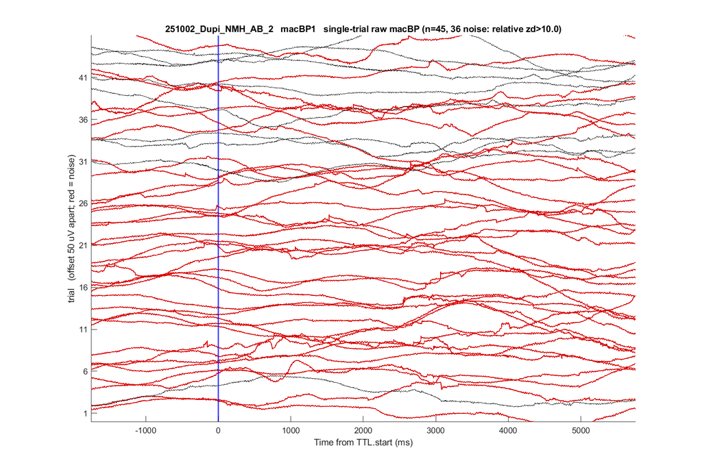

**Lowest-noise sessions:**

## 4. Single-subject example spectrograms

For each group, one example session, all three odor conditions (low / med / air), all finalOnset-locked.

### DupiS1

**250623_Dupi_NMH_KS_1** (bestMac = macBP2)

*low-odor:*

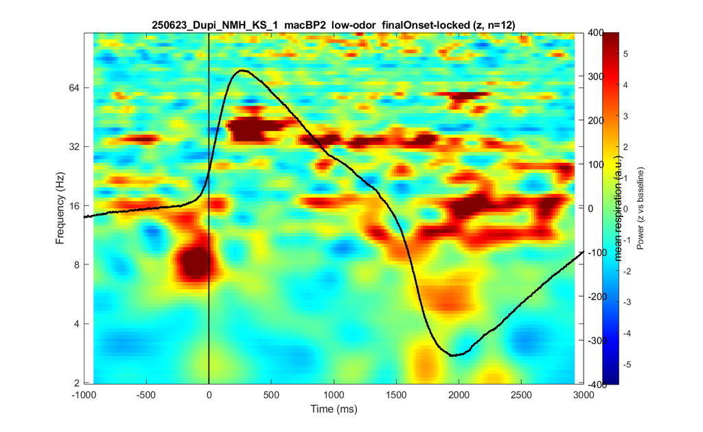

*med-odor:*

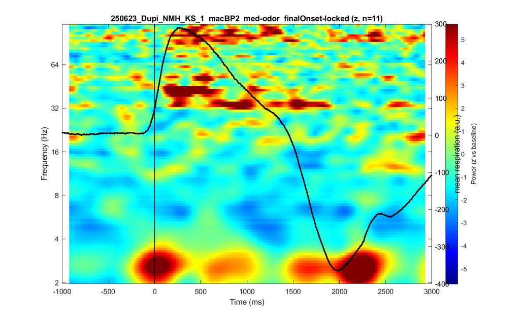

*air-odor:*

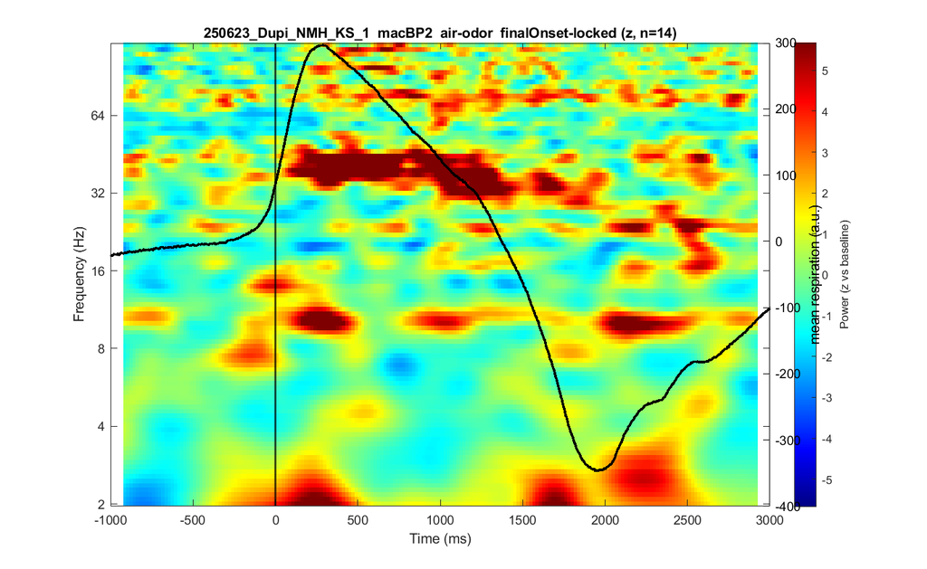

### DupiS2

**250623_Dupi_NMH_KS_2** (bestMac = macBP3)

*low-odor:*

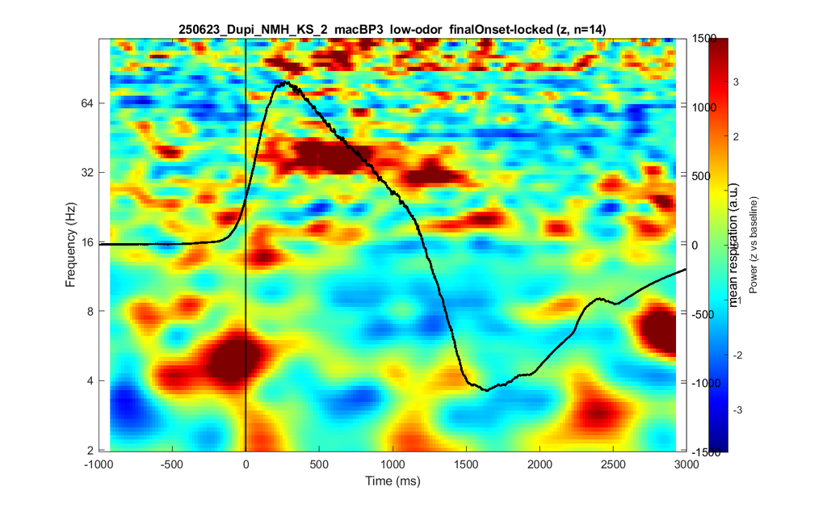

*med-odor:*

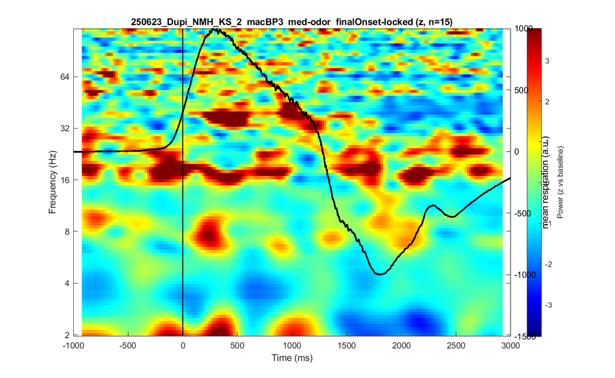

*air-odor:*

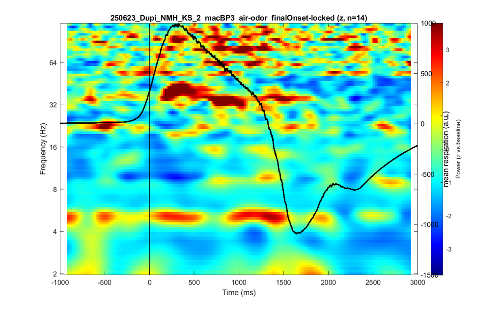

### DupiS3

**250623_Dupi_NMH_KS_3** (bestMac = macBP2)

*low-odor:*

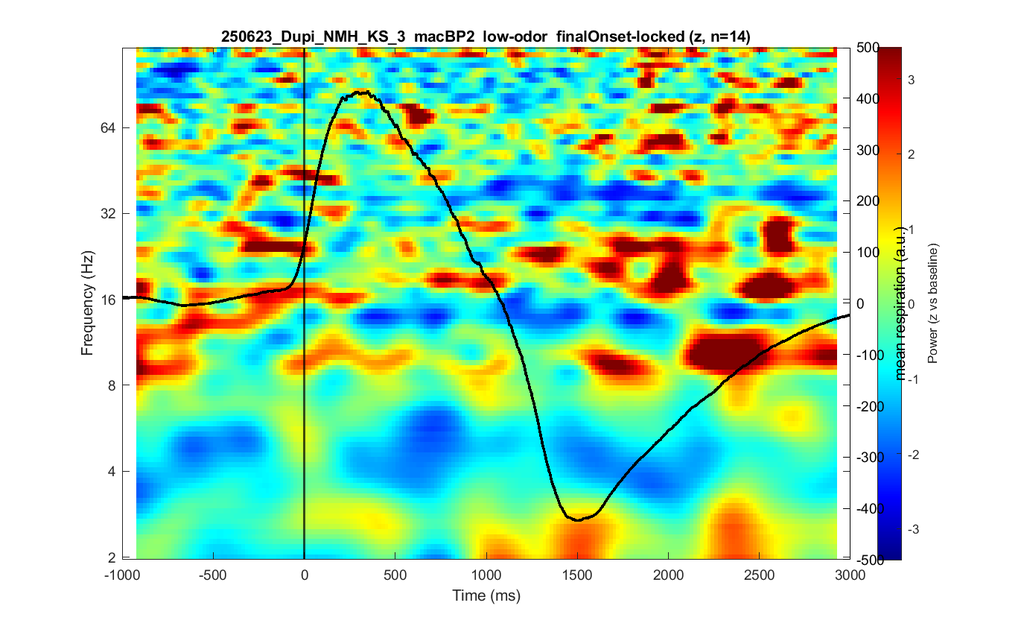

*med-odor:*

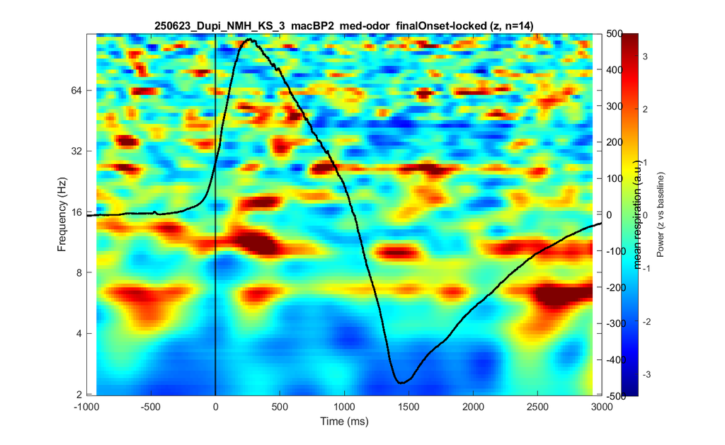

*air-odor:*

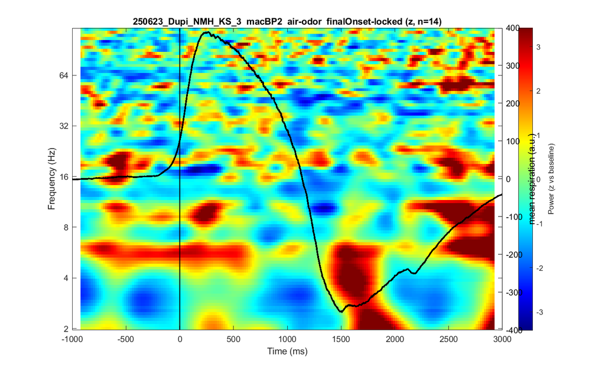

### Control

**260514_OBE_NWU_BW_1** (bestMac = macBP2)

## 5. Group-average spectrograms

4 groups × 3 odor conditions (low / med / air), shared ±5 z color scale.

### DupiS1

*low-odor:*

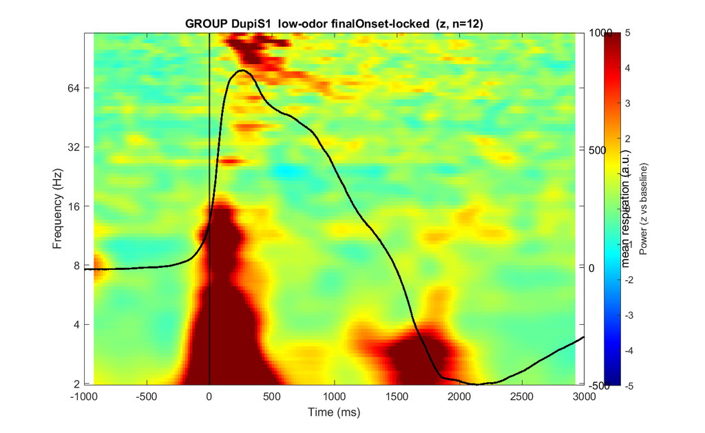

*med-odor:*

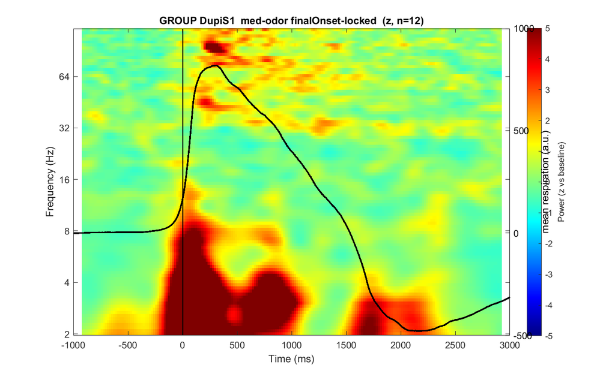

*air-odor:*

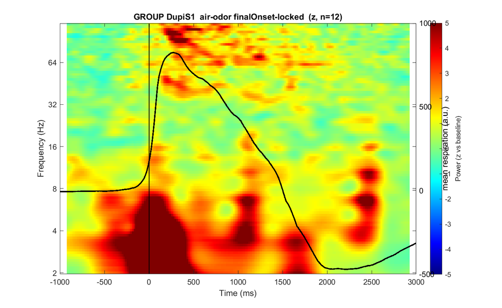

### DupiS2

*low-odor:*

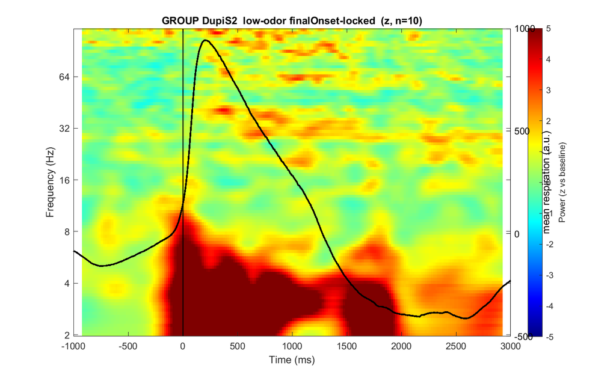

*med-odor:*

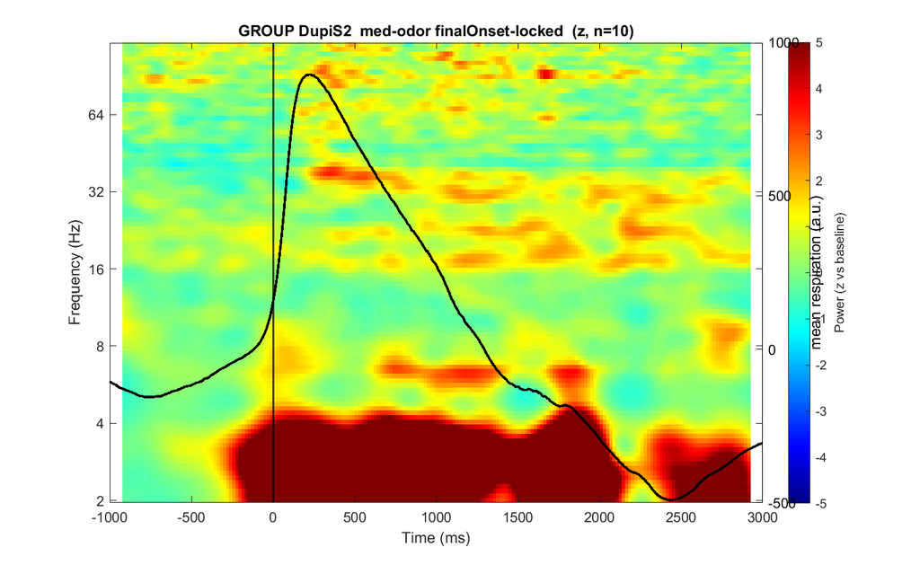

*air-odor:*

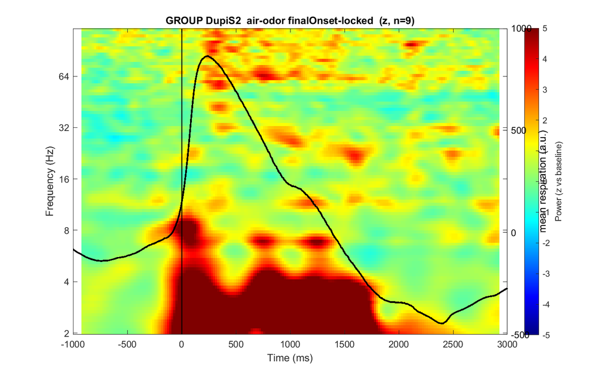

### DupiS3

*low-odor:*

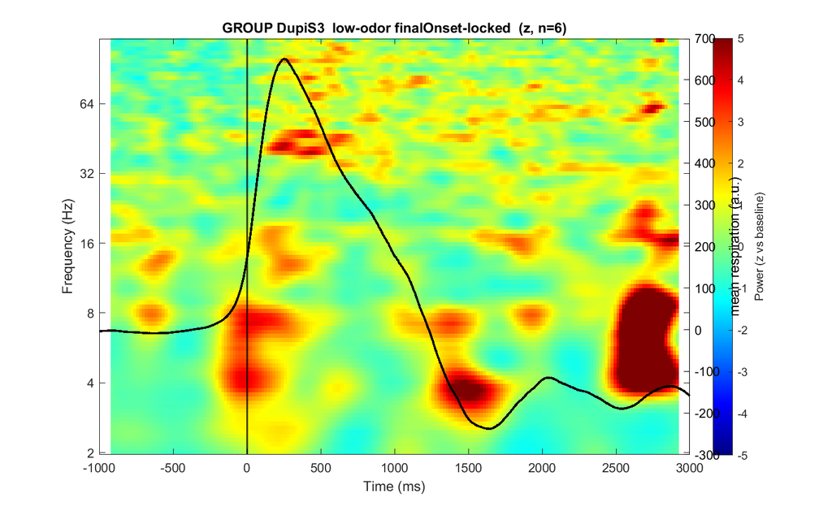

*med-odor:*

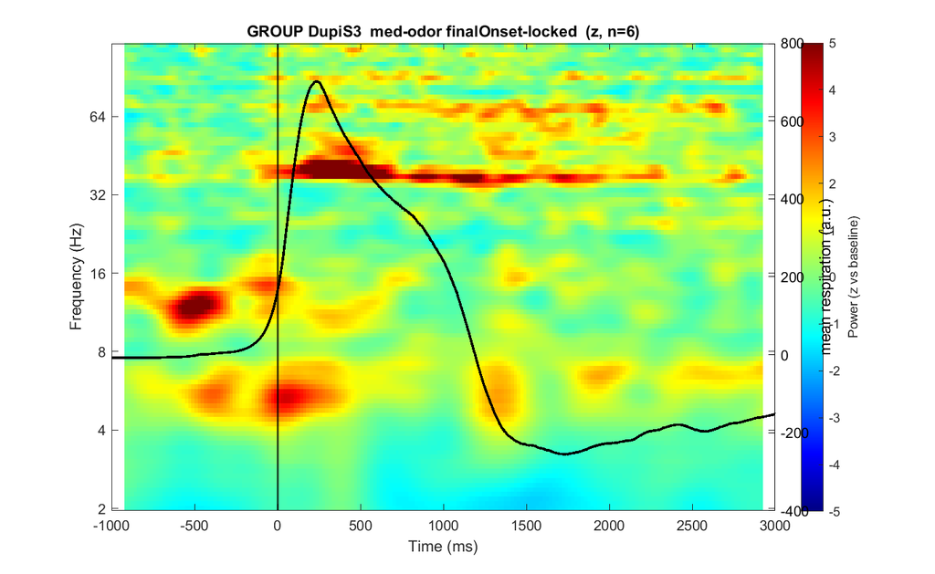

*air-odor:*

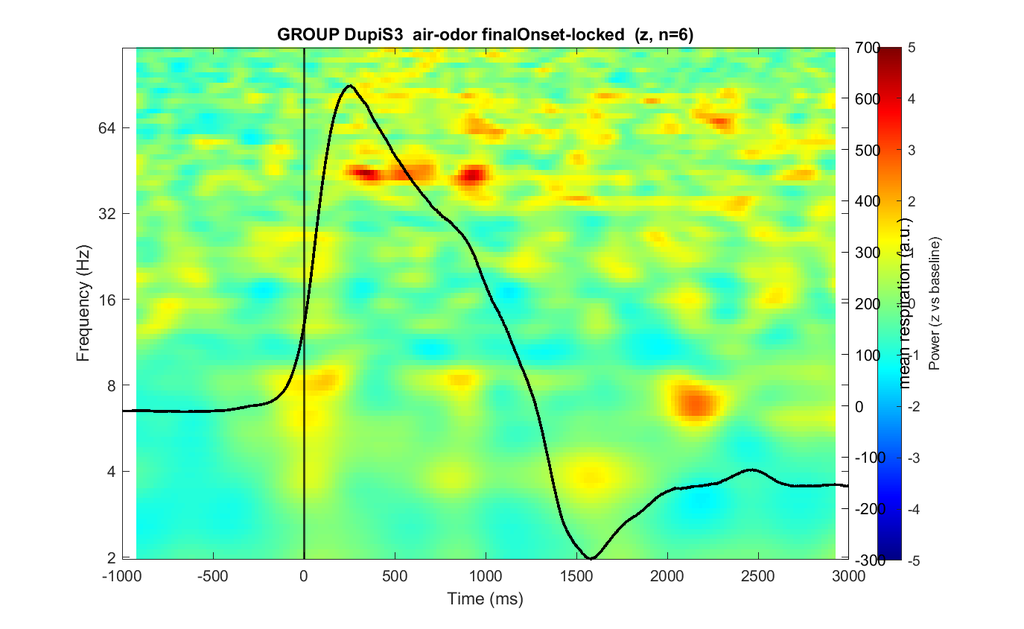

### Control

*low-odor:*

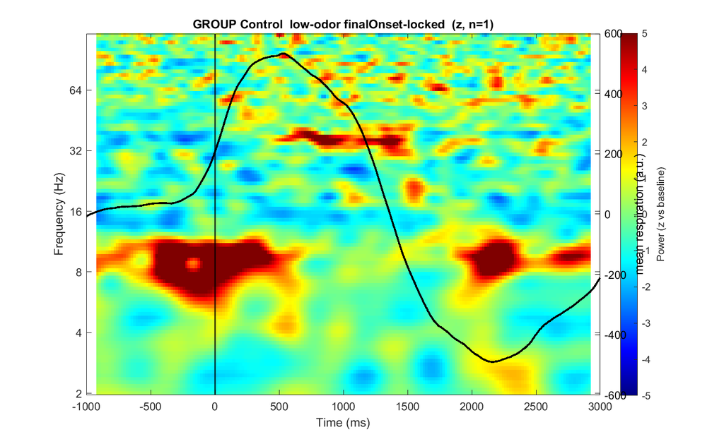

*med-odor:*

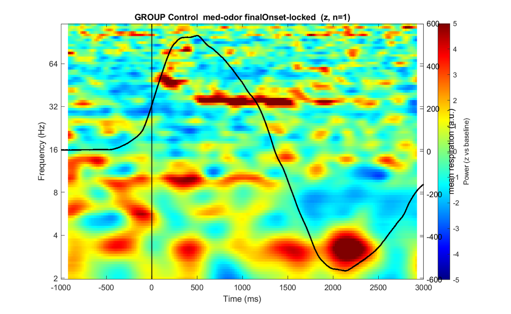

*air-odor:*

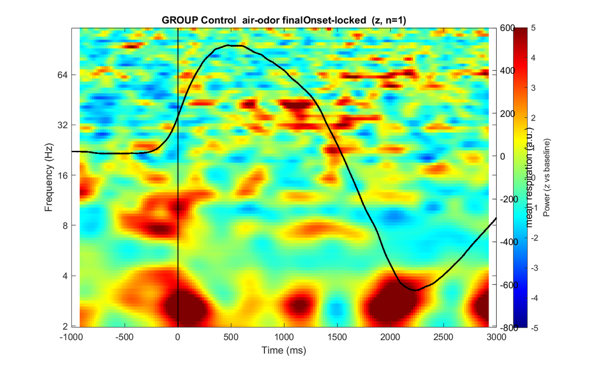

## 6. Time-resolved gamma (FOOOF over epochs, per odor condition)

**Methods.** For each session’s `bestMac`, per odor condition, Morlet power (2–58 Hz, 100 linear freqs) was computed on that condition’s noise-clean finalOnset-locked trials, then averaged over trials and into ten sequential **250 ms windows** spanning −500…+2000 ms. FOOOF (same settings as the overall channel fit) was applied to each window; the largest 30–58 Hz periodic peak per window is recorded in `threshTask_gammaEpochs.csv` (with a `cond` column). A condition with fewer than 8 clean trials in a session is skipped for that session. “Channel-centered” = each window’s gamma peak frequency minus that channel’s overall gamma peak (from §3).

### 6.1 Example gamma time-progression (one per group, three conditions)

**250623_Dupi_NMH_KS_1 (DupiS1)**

*low-odor:*

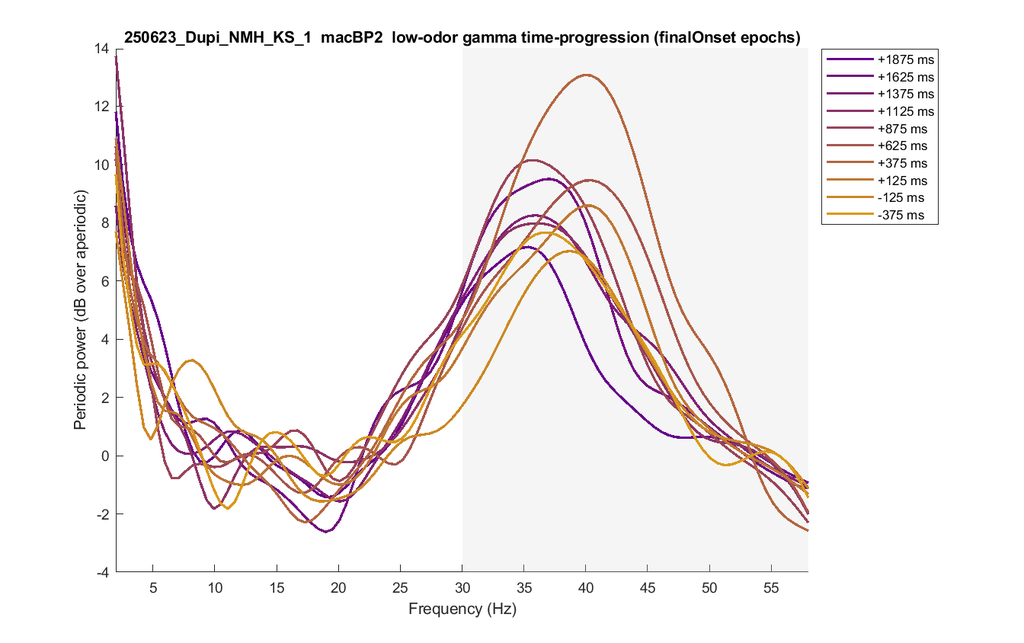

*med-odor:*

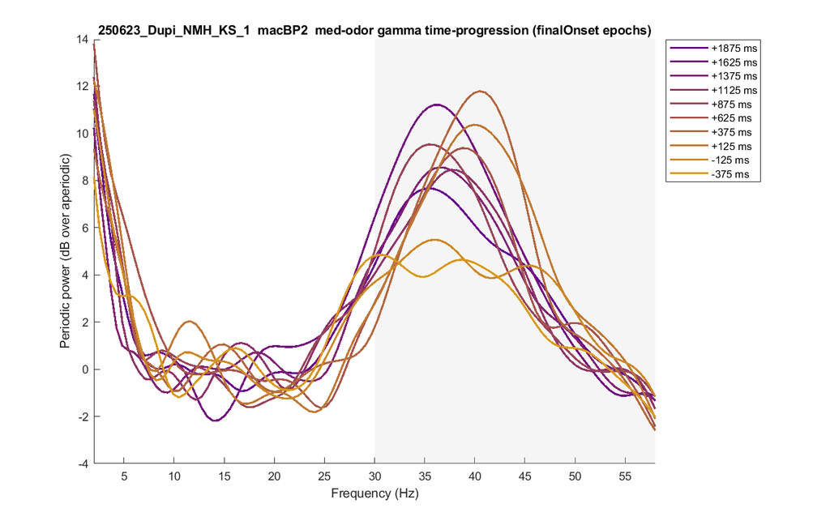

*air-odor:*

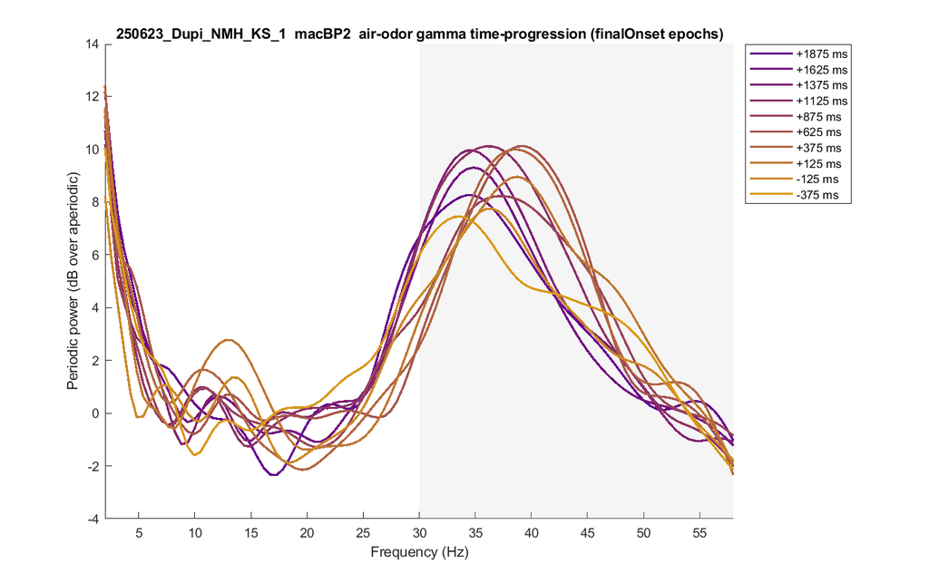

**250623_Dupi_NMH_KS_2 (DupiS2)**

*low-odor:*

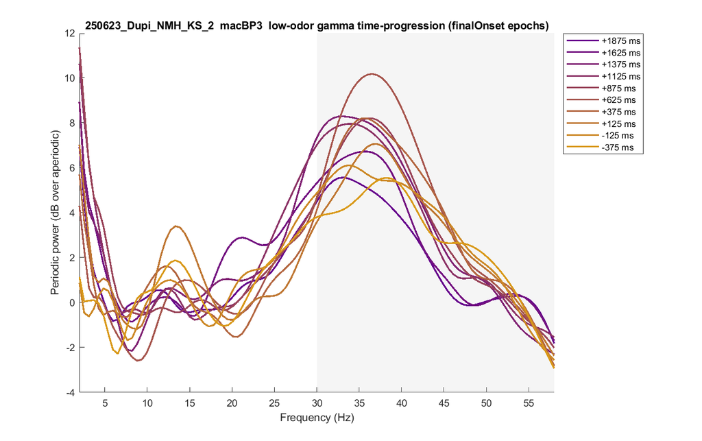

*med-odor:*

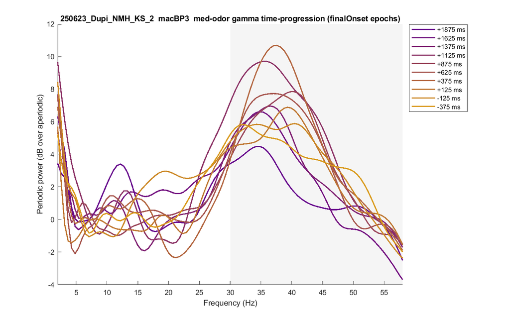

*air-odor:*

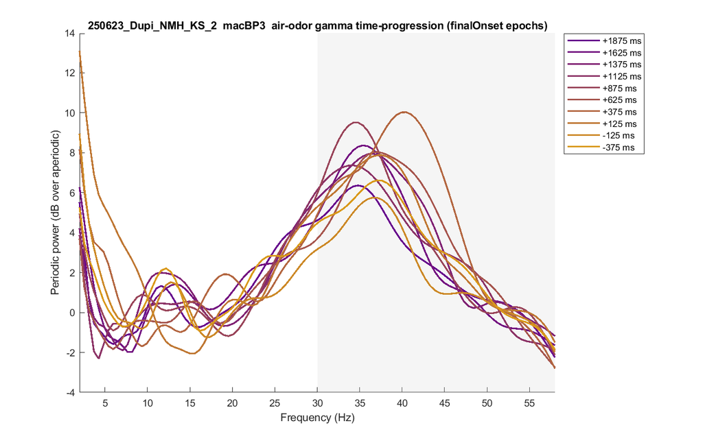

**250623_Dupi_NMH_KS_3 (DupiS3)**

*low-odor:*

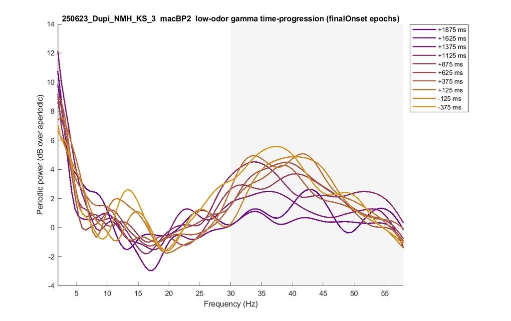

*med-odor:*

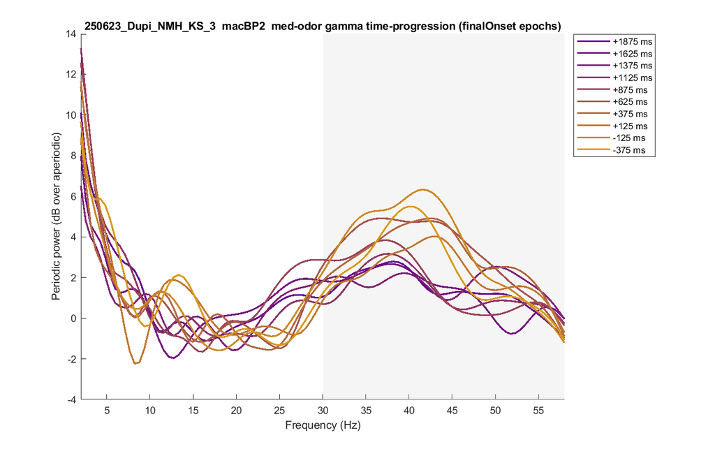

*air-odor:*

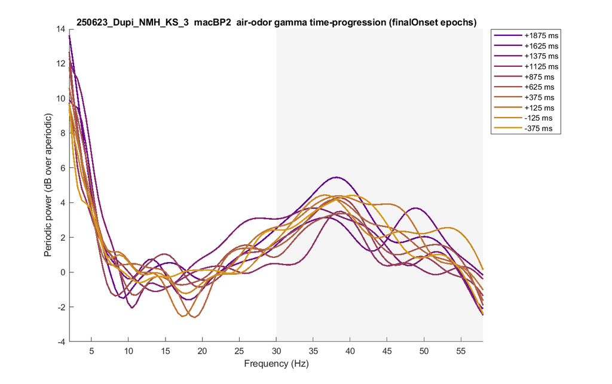

**260514_OBE_NWU_BW_1 (Control)**